# S2 - Crecimiento económico de los E-sports en los Estados Unidos

## Grupo N°2

### Integrantes:

- Dominguez Aspilcueta, Pedro Francisco
- Del Olmo Dulong, Juan Ignacio
- Chamorro Torres, Jean Pierre
- Munguia Cruzatt, Mauro Sthepano
- Ramos Torres, Guido Antonio **(Líder)**

# 1 Introducción

El tema que trata nuestra investigación es sobre la variación económica de los equipos y jugadores de E-sports en los Estados unidos entre los años 2019 y 2020. Para realizar un estudio más completo también se consideran los torneos internacionales en los que participaron jugadores y equipos estadounidenses.

## 1.1 Importancia

La investigación es de importancia para los equipos de E-sport peruanos en proceso de crecimiento, por ejemplo: las casas de juegos o “Gaming Houses’”, torneos locales, torneos entre universidades. Estos torneos son de consumo recurrente en jóvenes adolescentes y muy competitivos. Es así que la alta demanda de equipos muestra tendencias favorables de inversión que podrían ser de valor para pequeños empresarios que están interesados en el mercado E-sport.

Mostrar el crecimiento económico de las E-sports en otros países podría disponer de un mayor panorama para las empresas nacionales interesadas en desarrollar este tipo de torneos en el país.

## 1.2 Objetivos del estudio

Nuestros objetivos se pueden resumir en tres: Hallar relaciones económicas entre juego y grupo de hereditario de jóvenes, por cada torneo ejecutado. Proporcionar información sobre el comportamiento y tiempo de ejecución de cada juego, para hallar un balance entre el tiempo de cada juego contra el monto ganado por torneo. Realizar una predicción para ser de utilidad en la toma de decisiones al momento de invertir un capital en un equipo de E-sports.

## 1.4 Hipótesis

- ¿La categoría del juego influye de manera positiva o negativa en la cantidad de dinero que puede ganar un jugador?
- ¿La categoría del juego influye de manera positiva o negativa en la cantidad de dinero que puede ganar un equipo?
- ¿La nacionalidad del jugador esta relacionado con la cantidad de dinero que genera?
- ¿El hecho de que haya aumentado el número de torneos a lo largo de los años ha permitido que aumente el número diferente de jugadores que han generado ingresos?
- ¿La cantidad de torneos donde participan los jugadores está relacionado con la cantidad de dinero generado?
- ¿La cantidad de torneos donde participan los equipos está relacionado con la cantidad de dinero generado?

```r
Tipo <- read_csv("GeneralEsportData.csv")
```

```r
Fechas <- read_csv("HistoricalEsportData.csv")
Monto <- read_csv("highest_earning_teams.csv")
Competitive <- read_csv("competitive_game.csv")
```

# 2 Presentación de las variables y parámetros de estudio

## 2.1 Variables del estudio

| Pregunta | Variable | Tipo de variable | Restricciones |
| --- | --- | --- | --- |
| ¿Cuál es el nombre del juego? | Juego | Nominal | Juegos que al menos hayan tenido un torneo |
| ¿Cuál es el monto de premios total en todos sus torneos? | Ganancias por torneos totales | Continua | Real mayor a cero |
| ¿Cuál es el monto de premios total en torneos en línea? | Ganancias por torneos virtuales | Continua | Real mayor a cero |
| Por cada juego, ¿cuántos jugadores han ganado torneos? | Número de jugadores ganadores | Discreta | Entero mayor a cero |
| Por cada juego, ¿cuánto ha ganado cada equipo de E-sport? | Ganancias por equipos | Continua | Real mayor a cero |
| Por cada juego, ¿cuánto dinero total se ha premiado? | Ganancias totales | Continua | Real mayor a cero |
| Por cada juego, ¿cuántos torneos se realizaron en un período? | Número de torneos | Discreta | Real mayor a cero |
| Por cada juego, ¿en qué mes y año se realizaron sus torneos? | Fecha de cada torneo | Ordinal | Años entre 2019 a 2020 |
| ¿Cuál es el año de lanzamiento del juego? | Año de lanzamiento | Ordinal | Después de 1980 |

## 2.2 Descriptores numéricos

TotalEarnings

```r
mediaTotalEarnings = mean(Tipo$TotalEarnings)

round(mediaTotalEarnings,2)
```

```
## [1] 1873168
```

La media es la más adecuada, ya que, al tratarse de dinero como un volumen de ingreso, lo que nos interesa saber es cuanta es la cantidad total de ingreso por torneo. Dado que el ingreso es acumulativo, se debe incluir todos los datos atípicos para que la media sea menos robusta. Este es un valor que representa el ingreso total de cada juego previo a la medición y tiene ventaja si se le multiplica por la cantidad de observaciones.

OnlineEarnings

```r
mediaOnlineEarnings = mean(Tipo$OnlineEarnings, na.rm=TRUE)
round(mediaOnlineEarnings,2)
```

```
## [1] 1404852
```

Al igual que el caso anterior determinar la media adecuada es al igual una variable que tiene referencia a la cantidad de ingresos en dólares de los equipos de video juegos. La media en este casi representa el ingreso casi diarios de cada tipo de juegos.

Players

```r
mediaPlayers = mean(Tipo$TotalPlayers, na.rm = TRUE)

round(mediaPlayers,0)
```

```
## [1] 196
```

Dado de que se trata de personas, decidimos usar la media. De esta manera obtenemos un valor que representa el numero de participantes en cada tipo de juego, Además, si esta valor es multiplicado por la observaciones se obtiene el volumen de ingreso por equipo.

EarningsTor

```r
mediaEarningsTor = mean(Fechas$Earnings, na.rm = TRUE)
round(mediaEarningsTor,2)
```

```
## [1] 145427.7
```

Esto representa la cantidad media de los torneos durante la fecha establecida.

Juego

```r
modaJuego = mfv(Fechas$Game)
modaJuego
```

```
## [1] "StarCraft: Brood War"
```

Aquí es mejor la moda por que nos interesa saber el juego que mas se consume. No se uso moda en la variables por no considerar valores muy extremos.

### 2.3 Descriptores gráficos

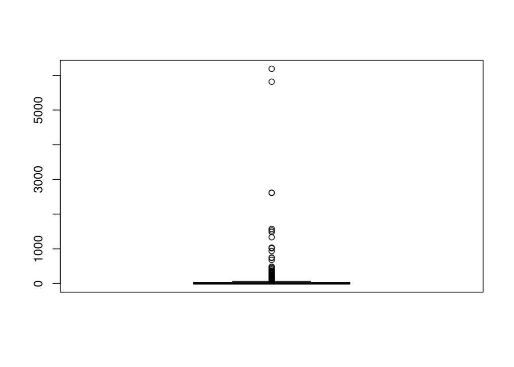

```r
boxplot(Tipo$TotalTournaments)
```

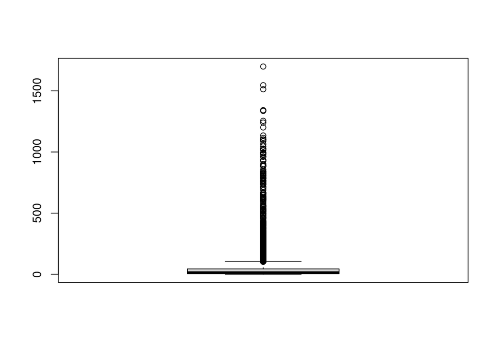

```r
boxplot(Fechas$Players)
```